```python
from IPython.core.display import HTML
HTML("""
<style>


div.cell { /* Tunes the space between cells */
    margin-top:1em;
    margin-bottom:3em;
}

div.text_cell_render { /* Customize text cells */
    font-family:  Times New Roman, Times, serif;
    font-weight: 500;
    font-size:1.2em;
    line-height:1.2em;
    padding-left:3em;
    padding-right:3em;
}
</style>
""")
```

# Euclidean Distance

Given a Cartesian coordinate system, the Eculidean distance between two vectors $\textbf{u}$ and $\textbf{v}$ is defined as:

\begin{equation} d(\textbf{u}, \textbf{v}) = d(\textbf{v}, \textbf{u}) = \sqrt{\sum_{i=1}^{n} (\textbf{u}_i - \textbf{v}_i)^2} \end{equation}

This is also known as $\ell^2$ distance between $\textbf{u}$ and $\textbf{v}$, or the $\ell^2$-norm of $\textbf{u} - \textbf{v}$:

\begin{equation} \| \textbf{u} - \textbf{v} \|_2 \end{equation}

Implement Euclidean distance with Numpy

```python
import numpy as np
def euclidean_dist(u, v):
    return np.sqrt(np.sum((u - v) ** 2))
```

```python
import numpy as np
u = np.random.rand(10)
v = np.random.rand(10)
u, v
```

```
(array([ 0.93172831,  0.49052025,  0.77498205,  0.19164708,  0.24641851,
         0.73039853,  0.55677181,  0.86616412,  0.32621084,  0.57128787]),
 array([ 0.95357743,  0.63978279,  0.05951702,  0.2527409 ,  0.40448094,
         0.68076964,  0.59011232,  0.55031599,  0.63258073,  0.79997238]))
```

```python
np.sqrt(np.sum((u - v) ** 2))
```

```
0.90158574523481549
```

如果实现正确, 运行下方代码时不应该出现 `AssertionError` 或 `TypeError`

```python
import numpy as np
from scipy.spatial.distance import euclidean
for _ in range(10):
    u = np.random.rand(50)
    v = np.random.rand(50)
    assert np.isclose(euclidean_dist(u, v), np.linalg.norm(u - v))
    assert np.isclose(euclidean_dist(u, v), euclidean(u, v))
print('Your implementation is correct.')
```

```
Your implementation is correct.
```

# Machine Learning 机器学习

"Machine learning is a field of computer science that gives computers the ability to learn without being explicitly programmed."

## A taste of Machine Learning: K-Nearest Neighbour分类算法

```python
import pickle

knn_data = pickle.load(open('knndata.pkl', 'rb'))
type(knn_data), len(knn_data)
```

```
(list, 4)
```

```python
data_known, data_unknown, label_known, label_unknown = knn_data
data_known.shape, label_known.shape
```

```
((20, 2), (20,))
```

```python
data_known
```

```
array([[-0.91913464, -2.7228335 ],
       [ 0.44309015,  4.22363693],
       [ 7.03333317, -5.0391912 ],
       [ 0.54993866, -2.86115247],
       [ 6.7584476 , -6.34496986],
       [-0.33999817,  5.30736013],
       [-0.64380612, -2.6208809 ],
       [ 1.56856295, -3.24302159],
       [ 1.20229934,  5.53934353],
       [ 1.72748609, -2.92715801],
       [ 6.63192522, -4.54913698],
       [ 5.88461451, -6.60200187],
       [ 8.24536559, -4.93032748],
       [ 6.34375399, -4.24235083],
       [ 7.56510452, -7.39263012],
       [ 0.97660475, -2.70385456],
       [ 5.17785648, -4.40766482],
       [ 0.31146637, -2.48066592],
       [-1.40061123,  5.35833117],
       [ 6.4683988 , -6.11797036]])
```

```python
label_known
```

```
array([2, 1, 0, 2, 0, 1, 2, 2, 1, 2, 0, 0, 0, 0, 0, 2, 0, 2, 1, 0])
```

```python
np.unique(label_known)
```

```
array([0, 1, 2])
```

```python
data_unknown.shape, label_unknown.shape
```

```
((10, 2), (10,))
```

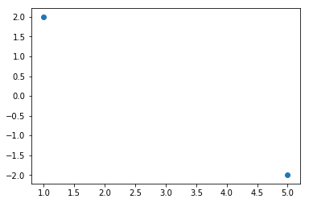

```python
import matplotlib.pyplot as plt
plt.scatter([1.0, 5.0], [2.0, -2])
plt.show()
```

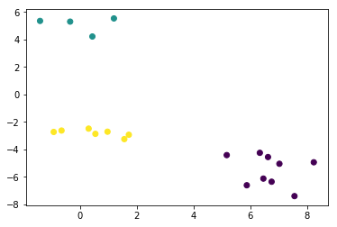

```python
plt.scatter(data_known[:, 0], data_known[:, 1], c=label_known)
plt.show()
```

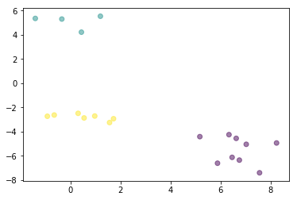

```python
plt1 = plt.scatter(*data_known.T, c=label_known, alpha=0.5)
plt.show()
```

```python
data_known.shape
```

```
(20, 2)
```

```python
plt.scatter(data_known[:, 0], data_known[:, 1], c=label_known, alpha=0.5)
```

```python
plt2 = plt.scatter(data_unknown[:, 0], data_unknown[:, 1], c='black', marker='^')
plt.legend([plt2], ['unknown'])
```

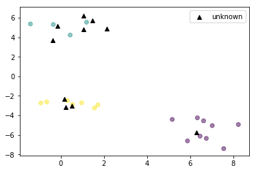

```python
plt.show()
```

```python
import numpy as np
from scipy.stats import mode

def euclidean_dist(u, v):
    return np.sqrt(np.sum((u - v) ** 2))

k = 3

predictions = []

for i, unknown_sample in enumerate(data_unknown):
    neighbours = []

    for j, observed_sample in enumerate(data_known):
        distance = euclidean_dist(unknown_sample, observed_sample)
        neighbours.append([distance, label_known[j]])

    neighbours = np.array(neighbours)
    knn = neighbours[neighbours[:, 0].argsort()][:k]
    predictions.append(mode(knn[:, 1])[0])

print('Ground truth: ', np.ravel(label_unknown))
print('Prediction: ', np.ravel(predictions))
```

```
Ground truth:  [1 2 2 1 2 1 1 1 1 0]
Prediction:  [ 1.  2.  2.  1.  2.  1.  1.  1.  1.  0.]
```

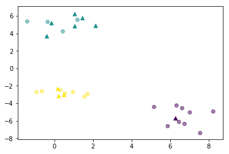

```python
plt1 = plt.scatter(data_known[:, 0], data_known[:, 1], c=label_known, alpha=0.5)
plt2 = plt.scatter(data_unknown[:, 0], data_unknown[:, 1], c=predictions, marker='^')
plt.show()
```

```python
unknown_sample = data_unknown[0]
unknown_sample_label = label_unknown[0]
unknown_sample, unknown_sample_label
```

```
(array([ 2.15163874,  4.85890208]), 1)
```

```python
import numpy as np

def euclidean_dist(u, v):
    return np.sqrt(np.sum((u - v) ** 2))
k=3


# unknown_sample = data_unknown[0]
# unknown_sample_label = label_unknown[0]
predictions = []
for unknown_sample in data_unknown:
    neighbours = []

    for i, known_sample in enumerate(data_known):

        distance = euclidean_dist(unknown_sample, known_sample)

        neighbours.append([label_known[i] ,distance])

    neighbours = np.array(neighbours)

    all_nearest_labels = neighbours[:, 0][np.argsort(neighbours[:, 1])]

    k_nearest_labels = all_nearest_labels[:k]

    from scipy.stats import mode

    predicted_label = mode(k_nearest_labels)[0]
    predictions.append(predicted_label)

np.ravel(predictions), label_unknown
```

```
(array([ 1.,  2.,  2.,  1.,  2.,  1.,  1.,  1.,  1.,  0.]),
 array([1, 2, 2, 1, 2, 1, 1, 1, 1, 0]))
```

### 归一化 normalisation

```python
x1 = np.arange(10, 110, 10)
x2 = np.arange(1, 11, 1)
x = np.vstack([x1, x2]).T
x
```

```
array([[ 10,   1],
       [ 20,   2],
       [ 30,   3],
       [ 40,   4],
       [ 50,   5],
       [ 60,   6],
       [ 70,   7],
       [ 80,   8],
       [ 90,   9],
       [100,  10]])
```

```python
(x - x.min(axis=0)) / (x.max(axis=0) - x.min(axis=0))
```

```
array([[ 0.        ,  0.        ],
       [ 0.11111111,  0.11111111],
       [ 0.22222222,  0.22222222],
       [ 0.33333333,  0.33333333],
       [ 0.44444444,  0.44444444],
       [ 0.55555556,  0.55555556],
       [ 0.66666667,  0.66666667],
       [ 0.77777778,  0.77777778],
       [ 0.88888889,  0.88888889],
       [ 1.        ,  1.        ]])
```

## 机器学习的组成要素

机器学习的三个组成要素:

1. 计算机可以理解的经验 (模型)
2. 经验概括能力好坏的度量标准 (目标函数)
3. 选择更合适的经验以获得更好的概括能力 (模型优化)

机器学习通常被分为监督(supervised)和非监督(unsupervised)学习. 详见 https://en.wikipedia.org/wiki/Machine_learning

[figure not shown]

## Supervised Learning 有监督的机器学习

给算法提供问题描述和对应的答案, 或者解决步骤和对应的反馈, 让算法概括如何解决问题

## 回归问题

给定不同地区的收入, 学校师生比等等共13列数据, 和该地区对应的房价中位数, 让算法概括如何根据这些数据来估算一个地区的房价

```python
for col_description in open('boston_housing_desc.txt', 'r').readlines():
    print(col_description)
```

```
1. CRIM - per capita crime rate by town

2. ZN - proportion of residential land zoned for lots over 25,000 sq.ft.

3. INDUS - proportion of non-retail business acres per town.

4. CHAS - Charles River dummy variable (1 if tract bounds river; 0 otherwise)

5. NOX - nitric oxides concentration (parts per 10 million)

6. RM - average number of rooms per dwelling

7. AGE - proportion of owner-occupied units built prior to 1940

8. DIS - weighted distances to five Boston employment centres

9. RAD - index of accessibility to radial highways

10. TAX - full-value property-tax rate per $10,000

11. PTRATIO - pupil-teacher ratio by town

12. B - 1000(Bk - 0.63)^2 where Bk is the proportion of blacks by town

13. LSTAT - % lower status of the population

14. MEDV - Median value of owner-occupied homes in $1000's
```

```python
import pandas as pd
housing = pd.read_csv('boston_housing_m.csv', delimiter=',')
housing.head(10)
```

|  | CRIM | ZN | INDUS | CHAS | NOX | RM | AGE | DIS | RAD1 | TAX1 | PTRATIO1 | B1 | LSTAT1 | MEDV |
| --- | --- | --- | --- | --- | --- | --- | --- | --- | --- | --- | --- | --- | --- | --- |
| 0 | 0.00632 | 18.0 | 2.31 | 0.0 | 0.538 | 6.575 | 65.2 | 4.0900 | 0.0 | 296.0 | 15.3 | 396.90 | 4.98 | 24.0 |
| 1 | 0.02731 | 0.0 | 7.07 | 0.0 | 0.469 | 6.421 | 78.9 | 4.9671 | 2.0 | 242.0 | 17.8 | 396.90 | 9.14 | 21.6 |
| 2 | 0.02729 | 0.0 | 7.07 | 0.0 | 0.469 | 7.185 | 0.0 | 4.9671 | 2.0 | 242.0 | 17.8 | 392.83 | 4.03 | 34.7 |
| 3 | 0.03237 | 0.0 | 2.18 | 0.0 | 0.458 | 6.998 | 45.8 | 6.0622 | 3.0 | 0.0 | 18.7 | 394.63 | 2.94 | 33.4 |
| 4 | 0.06905 | 0.0 | 2.18 | 0.0 | 0.458 | 7.147 | 54.2 | 6.0622 | 3.0 | 222.0 | 18.7 | 396.90 | 5.33 | 36.2 |
| 5 | 0.02985 | 0.0 | 2.18 | 0.0 | 0.458 | 6.430 | 58.7 | 6.0622 | 3.0 | 222.0 | 18.7 | 394.12 | 5.21 | 28.7 |
| 6 | 0.08829 | 12.5 | 7.87 | 0.0 | 0.524 | 6.012 | 66.6 | 5.5605 | 5.0 | 311.0 | 0.0 | 395.60 | 12.43 | 22.9 |
| 7 | 0.14455 | 12.5 | 7.87 | 0.0 | 0.524 | 6.172 | 96.1 | 5.9505 | 5.0 | 311.0 | 15.2 | 396.90 | 19.15 | 27.1 |
| 8 | 0.21124 | 12.5 | 0.00 | 0.0 | 0.524 | 5.631 | 100.0 | 6.0821 | 5.0 | 311.0 | 15.2 | 386.63 | 29.93 | 16.5 |
| 9 | 0.17004 | 12.5 | 7.87 | 0.0 | 0.524 | 6.004 | 85.9 | 6.5921 | 5.0 | 311.0 | 15.2 | 386.71 | 17.10 | 18.9 |

### 分类问题

给定一些鸢尾花(iris)的花萼长, 花萼宽, 花瓣长和花瓣宽的测量结果, 和与之对应的三个品种: {setosa, versicolor, virginica}, 让算法概括如何在已知这些测量结果的前提下准确地判断花的品种.

```python
import pandas as pd
iris = pd.read_csv('iris.csv', delimiter=',')
iris.iloc[np.r_[0:5, 63:68, 125:130],:]
```

|  | Sepal length | Sepal width | Petal length | Petal width | Species |
| --- | --- | --- | --- | --- | --- |
| 0 | 5.2 | 3.5 | 1.4 | 0.2 | setosa |
| 1 | 4.9 | 3.0 | 1.4 | 0.2 | setosa |
| 2 | 4.7 | 3.2 | 1.3 | 0.2 | setosa |
| 3 | 4.6 | 3.1 | 1.5 | 0.2 | setosa |
| 4 | 5.0 | 3.6 | 1.4 | 0.3 | setosa |
| 63 | 6.1 | 2.9 | 4.7 | 1.4 | versicolor |
| 64 | 5.6 | 2.9 | 3.6 | 1.3 | versicolor |
| 65 | 6.7 | 3.1 | 4.4 | 1.4 | versicolor |
| 66 | 5.6 | 3.0 | 4.5 | 1.5 | versicolor |
| 67 | 5.8 | 2.7 | 4.1 | 1.0 | versicolor |
| 125 | 7.2 | 3.2 | 6.0 | 1.8 | virginica |
| 126 | 6.2 | 2.8 | 4.8 | 1.8 | virginica |
| 127 | 6.1 | 3.0 | 4.9 | 1.8 | virginica |
| 128 | 6.4 | 2.8 | 5.6 | 2.1 | virginica |
| 129 | 7.2 | 3.0 | 5.8 | 1.6 | virginica |

# 使用Pandas

#### 载入iris数据集

```python
import pandas as pd
import numpy as np
iris = pd.read_csv('iris.csv', delimiter=',')
print('数据集现在的类型是', type(iris))
print('所有的Species:', np.unique(iris['Species']))
print('数据集的前10行:')
iris.head(10)
```

```
数据集现在的类型是 <class 'pandas.core.frame.DataFrame'>
所有的Species: ['setosa' 'versicolor' 'virginica']
数据集的前10行:
```

|  | Sepal length | Sepal width | Petal length | Petal width | Species |
| --- | --- | --- | --- | --- | --- |
| 0 | 5.2 | 3.5 | 1.4 | 0.2 | setosa |
| 1 | 4.9 | 3.0 | 1.4 | 0.2 | setosa |
| 2 | 4.7 | 3.2 | 1.3 | 0.2 | setosa |
| 3 | 4.6 | 3.1 | 1.5 | 0.2 | setosa |
| 4 | 5.0 | 3.6 | 1.4 | 0.3 | setosa |
| 5 | 5.4 | 3.9 | 1.7 | 0.4 | setosa |
| 6 | 4.6 | 3.4 | 1.4 | 0.3 | setosa |
| 7 | 5.0 | 3.4 | 1.5 | 0.2 | setosa |
| 8 | 4.4 | 2.9 | 1.4 | 0.2 | setosa |
| 9 | 4.9 | 3.1 | 1.5 | 0.1 | setosa |

`DataFrame`可以看成是一个字典, 其中每一个key对应一个`Series`, 也即一列数据.

可以用`pd.DataFrame.as_matrix()`将其转为一个`ndarray`.

`DataFrame`也可以当成一个2维的`ndarray`使用, 但索引和slicing的方式不同

```python
iris.shape
```

```
(149, 5)
```

```python
print('DataFrame中的一列数据是一个Series',
      type(iris['Sepal length']))
```

```
DataFrame中的一列数据是一个Series <class 'pandas.core.series.Series'>
```

```python
try:
    iris[:10, [2,3, -1]]
except TypeError:
    print('DataFrame 的切割和索引方式与 ndarray 不同')

print('DataFrame 的切割和索引:')
iris.iloc[:10,[2,3,-1]]
```

```
DataFrame 的切割和索引方式与 ndarray 不同
DataFrame 的切割和索引:
```

|  | Petal length | Petal width | Species |
| --- | --- | --- | --- |
| 0 | 1.4 | 0.2 | setosa |
| 1 | 1.4 | 0.2 | setosa |
| 2 | 1.3 | 0.2 | setosa |
| 3 | 1.5 | 0.2 | setosa |
| 4 | 1.4 | 0.3 | setosa |
| 5 | 1.7 | 0.4 | setosa |
| 6 | 1.4 | 0.3 | setosa |
| 7 | 1.5 | 0.2 | setosa |
| 8 | 1.4 | 0.2 | setosa |
| 9 | 1.5 | 0.1 | setosa |

```python
iris.loc[:10,['Petal length', 'Petal width', 'Species']]
```

|  | Petal length | Petal width | Species |
| --- | --- | --- | --- |
| 0 | 1.4 | 0.2 | setosa |
| 1 | 1.4 | 0.2 | setosa |
| 2 | 1.3 | 0.2 | setosa |
| 3 | 1.5 | 0.2 | setosa |
| 4 | 1.4 | 0.3 | setosa |
| 5 | 1.7 | 0.4 | setosa |
| 6 | 1.4 | 0.3 | setosa |
| 7 | 1.5 | 0.2 | setosa |
| 8 | 1.4 | 0.2 | setosa |
| 9 | 1.5 | 0.1 | setosa |
| 10 | 1.5 | 0.2 | setosa |

可以用`pd.DataFrame.as_matrix()`将`DataFrame`转为一个`ndarray`

```python
iris_ndarray = iris.as_matrix()
print('iris_ndarray 现在的类型是', type(iris_ndarray))
print('iris 每一列的名称', iris.columns.values)
```

```
iris_ndarray 现在的类型是 <class 'numpy.ndarray'>
iris 每一列的名称 ['Sepal length' 'Sepal width' 'Petal length' 'Petal width' 'Species']
```

```python
iris_from_xls = pd.read_excel('iris.xlsx')
```

```python
iris_from_xls
```

|  | Sepal length | Sepal width | Petal length | Petal width | Species |
| --- | --- | --- | --- | --- | --- |
| 0 | 5.2 | 3.5 | 1.4 | 0.2 | setosa |
| 1 | 4.9 | 3.0 | 1.4 | 0.2 | setosa |
| 2 | 4.7 | 3.2 | 1.3 | 0.2 | setosa |
| 3 | 4.6 | 3.1 | 1.5 | 0.2 | setosa |
| 4 | 5.0 | 3.6 | 1.4 | 0.3 | setosa |
| 5 | 5.4 | 3.9 | 1.7 | 0.4 | setosa |
| 6 | 4.6 | 3.4 | 1.4 | 0.3 | setosa |
| 7 | 5.0 | 3.4 | 1.5 | 0.2 | setosa |
| 8 | 4.4 | 2.9 | 1.4 | 0.2 | setosa |
| 9 | 4.9 | 3.1 | 1.5 | 0.1 | setosa |
| 10 | 5.4 | 3.7 | 1.5 | 0.2 | setosa |
| 11 | 4.8 | 3.4 | 1.6 | 0.2 | setosa |
| 12 | 4.8 | 3.0 | 1.4 | 0.1 | setosa |
| 13 | 4.3 | 3.0 | 1.1 | 0.1 | setosa |
| 14 | 5.8 | 4.0 | 1.2 | 0.2 | setosa |
| 15 | 5.7 | 4.4 | 1.5 | 0.4 | setosa |
| 16 | 5.4 | 3.9 | 1.3 | 0.4 | setosa |
| 17 | 5.1 | 3.5 | 1.4 | 0.3 | setosa |
| 18 | 5.7 | 3.8 | 1.7 | 0.3 | setosa |
| 19 | 5.1 | 3.8 | 1.5 | 0.3 | setosa |
| 20 | 5.4 | 3.4 | 1.7 | 0.2 | setosa |
| 21 | 5.1 | 3.7 | 1.5 | 0.4 | setosa |
| 22 | 4.6 | 3.6 | 1.0 | 0.2 | setosa |
| 23 | 5.1 | 3.3 | 1.7 | 0.5 | setosa |
| 24 | 4.8 | 3.4 | 1.9 | 0.2 | setosa |
| 25 | 5.0 | 3.0 | 1.6 | 0.2 | setosa |
| 26 | 5.0 | 3.4 | 1.6 | 0.4 | setosa |
| 27 | 5.2 | 3.5 | 1.5 | 0.2 | setosa |
| 28 | 5.2 | 3.4 | 1.4 | 0.2 | setosa |
| 29 | 4.7 | 3.2 | 1.6 | 0.2 | setosa |
| ... | ... | ... | ... | ... | ... |
| 119 | 6.0 | 2.2 | 5.0 | 1.5 | virginica |
| 120 | 6.9 | 3.2 | 5.7 | 2.3 | virginica |
| 121 | 5.6 | 2.8 | 4.9 | 2.0 | virginica |
| 122 | 7.7 | 2.8 | 6.7 | 2.0 | virginica |
| 123 | 6.3 | 2.7 | 4.9 | 1.8 | virginica |
| 124 | 6.7 | 3.3 | 5.7 | 2.1 | virginica |
| 125 | 7.2 | 3.2 | 6.0 | 1.8 | virginica |
| 126 | 6.2 | 2.8 | 4.8 | 1.8 | virginica |
| 127 | 6.1 | 3.0 | 4.9 | 1.8 | virginica |
| 128 | 6.4 | 2.8 | 5.6 | 2.1 | virginica |
| 129 | 7.2 | 3.0 | 5.8 | 1.6 | virginica |
| 130 | 7.4 | 2.8 | 6.1 | 1.9 | virginica |
| 131 | 7.9 | 3.8 | 6.4 | 2.0 | virginica |
| 132 | 6.4 | 2.8 | 5.6 | 2.2 | virginica |
| 133 | 6.3 | 2.8 | 5.1 | 1.5 | virginica |
| 134 | 6.1 | 2.6 | 5.6 | 1.4 | virginica |
| 135 | 6.3 | 3.4 | 5.6 | 2.4 | virginica |
| 136 | 6.4 | 3.1 | 5.5 | 1.8 | virginica |
| 137 | 6.0 | 3.0 | 4.8 | 1.8 | virginica |
| 138 | 6.9 | 3.1 | 5.4 | 2.1 | virginica |
| 139 | 6.7 | 3.1 | 5.6 | 2.4 | virginica |
| 140 | 6.9 | 3.1 | 5.1 | 2.3 | virginica |
| 141 | 5.8 | 2.7 | 5.1 | 1.9 | virginica |
| 142 | 6.8 | 3.2 | 5.9 | 2.3 | virginica |
| 143 | 6.7 | 3.3 | 5.7 | 2.5 | virginica |
| 144 | 6.7 | 3.0 | 5.2 | 2.3 | virginica |
| 145 | 6.3 | 2.5 | 5.0 | 1.9 | virginica |
| 146 | 6.5 | 3.0 | 5.2 | 2.0 | virginica |
| 147 | 6.2 | 3.4 | 5.4 | 2.3 | virginica |
| 148 | 5.9 | 3.0 | 5.1 | 1.8 | virginica |

149 rows × 5 columns

```python
x1 = np.arange(10, 110, 10)
x2 = np.arange(1, 11, 1)
x = np.vstack([x1, x2]).T
(x - x.min(axis=0)) / (x.max(axis=0) - x.min(axis=0))
```

```
array([[ 0.        ,  0.        ],
       [ 0.11111111,  0.11111111],
       [ 0.22222222,  0.22222222],
       [ 0.33333333,  0.33333333],
       [ 0.44444444,  0.44444444],
       [ 0.55555556,  0.55555556],
       [ 0.66666667,  0.66666667],
       [ 0.77777778,  0.77777778],
       [ 0.88888889,  0.88888889],
       [ 1.        ,  1.        ]])
```

1. 用pandas 载入 iris 数据集
2. 用train_test_split 把数据集分为 训练集 和 测试集
3. 用前面实现的 knn 算法, 生成一个list of predictions, 包含测试集里每一个样本的预测值
4. 计算预测正确率

```python
from sklearn.model_selection import train_test_split
# from sklearn.cross_validation import train_test_split
X = iris[['Sepal length','Sepal width',
          'Petal length','Petal width']]
y = iris['Species']

X.shape, y.shape
```

```
((149, 4), (149,))
```

```python
X_train, X_test, y_train, y_test = train_test_split(
    X, y, test_size=0.33, random_state=42)

X_train.shape, X_test.shape, y_train.shape, y_test.shape
X_train.iloc[0], X_train.iloc[-1]
```

```
(Sepal length    5.7
 Sepal width     3.0
 Petal length    4.2
 Petal width     1.2
 Name: 95, dtype: float64, Sepal length    7.1
 Sepal width     3.0
 Petal length    5.9
 Petal width     2.1
 Name: 102, dtype: float64)
```